# Assignment/Homework 2 - Tam Nguyen

#### 1.

1. this is a histogram
2. the mean is about 630 yards/min. This is because the graph looks like the normal distribution and the mean tends to lie around the middle of the graph.
3. The median is the middle place, so the value I approximate is about 630 yards/min. This is because the graph is close to the normal distribution and in this case the median tends to have similar values with the mean.
4. The mode is the highest value so it’s around 1000 yards/min. I calculated it by seeing the highest bar.

#### 2.

```r
library(readr)
ReproductiveSuccess <- read_csv("SparrowReproductiveSuccess.csv")
male <- filter(ReproductiveSuccess, sex == "male")
female <- filter(ReproductiveSuccess, sex == "female")
```

1. mean for male: 1.51 mean for female: 1.69

–> females have higher mean of lifetime reproductive success.

```r
mean(male$lifetimeRS)
```

```
## [1] 1.511905
```

```r
mean(female$lifetimeRS)
```

```
## [1] 1.691358
```

```r
var(male$lifetimeRS)
```

```
## [1] 3.529977
```

```r
var(female$lifetimeRS)
```

```
## [1] 4.341049
```

3. females have a higher variance in reproductive success.
4. Variance for male: 3.53. variance for female: 4.34

```r
male4 <- filter(male, male$lifetimeRS >= 4)
female4 <- filter(female, female$lifetimeRS >= 4)
var(male4$lifetimeRS)
```

```
## [1] 0.3833333
```

```r
var(female4$lifetimeRS)
```

```
## [1] 2.029412
```

for males >= 4, variance is 0.38 for female >= 4, variance is 2.03

```r
# for man
6.7/sqrt(4620)
```

```
## [1] 0.09857206
```

```r
4.6/sqrt(6228)
```

```
## [1] 0.05828859
```

1. SE in men is 0.1, SE in woman is 0.06
2. In terms of variation among men in the number of sexual partner, the standard deviation is a better descriptor because it describes the variation of all males in the sample.
3. in terms of the uncertainty of the estimated mean number of partners in woman, the standard error is a better descriptor because it helps to quantify the variations and uncertainty of the mean.

#### 3.

```r
male <- filter(ReproductiveSuccess, sex == "male")
female <- filter(ReproductiveSuccess, sex == "female")
```

#### 4.

```r
beetles <- read_csv("Corpseflowers.csv")
describe(beetles$numberOfBeetles)
```

```
##    vars  n mean   sd median trimmed   mad min max range skew kurtosis
## X1    1 10 70.1 48.5   56.5   68.12 48.18   7 149   142  0.3    -1.43
##       se
## X1 15.34
```

1. mean = 70.1

sd = 48.5

se = 15.34

```r
70.1+15.34 #upper
```

```
## [1] 85.44
```

```r
70.1-15.34 #lower
```

```
## [1] 54.76
```

3. upper limit: 85.44 lower limit: 54.76
4. if the distribution is normal, if given 25 data points, the sampling distribution of the sample mean will be normal and will stay the same.
5. the standard deviation would get smaller as there are more data points.
6. the standard error would be smaller when there are 25 data points instead of 10

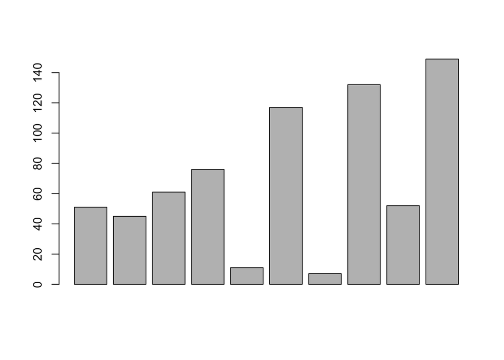

```r
barplot(beetles$numberOfBeetles)
```

```r
n25 <- round(rnorm(25, mean = 70.1, sd = 48.5))
n50 <-  round(rnorm(50, mean = 70.1, sd = 48.5))
n100 <-  round(rnorm(100, mean = 70.1, sd = 48.5))

describe(n25)
```

```
##    vars  n  mean    sd median trimmed   mad min max range  skew kurtosis
## X1    1 25 90.12 58.69    109   91.57 54.86 -58 224   282 -0.23     0.22
##       se
## X1 11.74
```

```r
describe(n50)
```

```
##    vars  n  mean    sd median trimmed   mad min max range  skew kurtosis
## X1    1 50 78.68 45.29   81.5   78.88 51.89 -19 162   181 -0.05    -0.76
##      se
## X1 6.41
```

```r
describe(n100)
```

```
##    vars   n  mean    sd median trimmed   mad min max range skew kurtosis
## X1    1 100 71.59 45.21   72.5    72.5 37.81 -66 210   276 -0.2     1.02
##      se
## X1 4.52
```

#### 5.

a strip bar shows every individual data point, which make it easier to visualise outliers in the each of the variable. The bar plot, on the other hand, obscures a lot of information so I think the strip bar is superior.

#### 6.

1. coach has the longest hugs, while competitor has the shortest hugs. These values only show sample estimates because this is taken from a sample

```r
3.96/sqrt(77)
```

```
## [1] 0.4512839
```

```r
2.76/sqrt(75)
```

```
## [1] 0.3186973
```

```r
1.13/sqrt(33)
```

```
## [1] 0.1967078
```

2. SE of coach: 0.45

SE of Supporter: 0.32

SE of competitor: 0.20

These values measure the uncertainty or the standard deviation of the sampling distribution of the sample mean.

Assumptions:

I assume that each of these samples has a normal distribution.

```r
1.81+0.45
```

```
## [1] 2.26
```

```r
1.81-0.45
```

```
## [1] 1.36
```

2 seconds is among the most plausible values for the population mean hug.

6. For the supporter, 3 second mean hug duration in the population is plausible